# Ultrarunning

Hanz

2023-11-09

The purpose of this function is to read the excel file that is going to be used for this project.

```r
library(readxl)
Ultra_running_for_project_use <- read_excel("C:/Users/Hanzd/Desktop/Ultra Running Analysis/Ultra running for project use.xlsx")
View(Ultra_running_for_project_use)
attach(Ultra_running_for_project_use)
Ultra_running_for_project_use= na.omit(Ultra_running_for_project_use)
names(Ultra_running_for_project_use)
```

```
##  [1] "age"         "sex"         "pb_surface"  "pb_elev"     "pb100k_time"
##  [6] "pb100k_dec"  "avg_km"      "teique_sf"   "steu_b"      "stem_b"
```

Now we will create a new data frame and clean the data we are given.

```r
Ultrarunning = data.frame(na.omit(Ultra_running_for_project_use))
View(Ultrarunning)
Ultrarunning$pb100k_time = NULL
View(Ultrarunning)
```

Since 0 values are ommited for being viable for a box-cox transformation

```r
Ultrarunning= data.frame(Ultrarunning[!(Ultrarunning$pb_elev %in% 0), ])
View(Ultrarunning)
```

We’re gonna be creating new variables based on data from the ultrarunning data frame so that it’s going to be easier to access.

```r
newAge = Ultrarunning$age
newSex = Ultrarunning$sex
newPb_surface= Ultrarunning$pb_surface
newPb_elev = Ultrarunning$pb_elev
newPb100k_dec = Ultrarunning$pb100k_dec
newAvg_km = Ultrarunning$avg_km
newTeique_sf = Ultrarunning$teique_sf
newSteu_b = Ultrarunning$steu_b
newStem_b = Ultrarunning$stem_b
```

Now we are going to analyze our summary statistics for each variable and analyze if their are any information that may prevent us from being able to use this model.

```r
summary(newAge)
```

```
##    Min. 1st Qu.  Median    Mean 3rd Qu.    Max.
##    19.0    32.0    37.5    39.6    45.0    87.0
```

```r
summary(newPb_surface)
```

```
##    Min. 1st Qu.  Median    Mean 3rd Qu.    Max.
##   1.000   1.000   1.000   1.536   1.000   4.000
```

```r
summary(newPb_elev)
```

```
##    Min. 1st Qu.  Median    Mean 3rd Qu.    Max.
##      30    1393    2708    2816    3818    9000
```

```r
summary(newPb100k_dec)
```

```
##    Min. 1st Qu.  Median    Mean 3rd Qu.    Max.
##    7.60   12.57   14.71   14.92   17.00   23.50
```

```r
summary(newAvg_km)
```

```
##    Min. 1st Qu.  Median    Mean 3rd Qu.    Max.
##    5.00   60.00   70.00   72.41   80.00  160.00
```

```r
summary(newTeique_sf)
```

```
##    Min. 1st Qu.  Median    Mean 3rd Qu.    Max.
##   3.133   4.733   5.200   5.174   5.633   6.500
```

```r
summary(newSteu_b)
```

```
##    Min. 1st Qu.  Median    Mean 3rd Qu.    Max.
##    7.00   12.00   13.00   13.15   15.00   18.00
```

```r
summary(newStem_b)
```

```
##    Min. 1st Qu.  Median    Mean 3rd Qu.    Max.
##   5.833  10.333  11.583  11.469  12.938  15.083
```

Since we’re going to be using Pb100k_dec as our response variable, we will also be analyzing the mean values of newPb100k_dec.

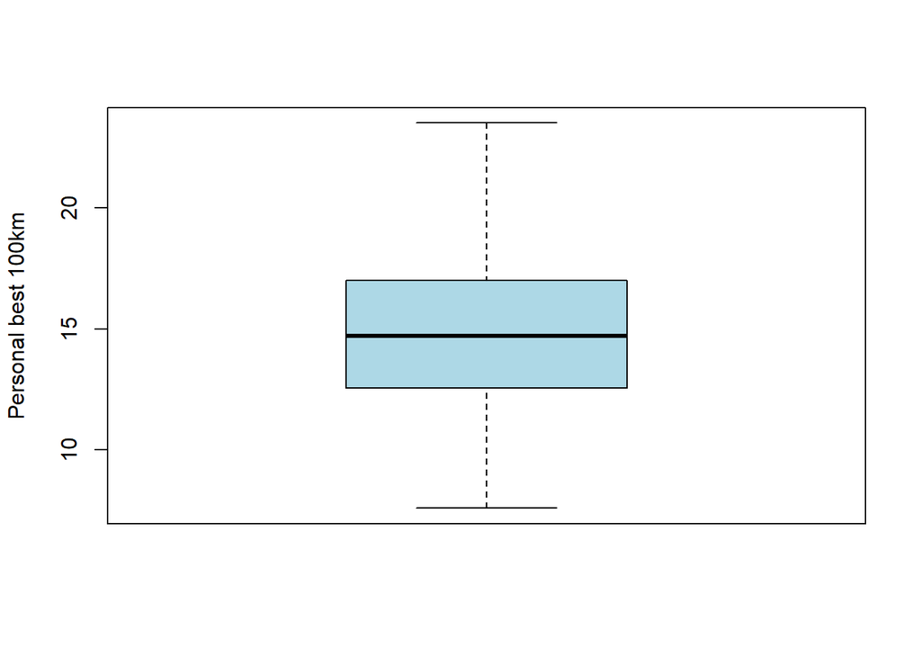

```r
boxplot(newPb100k_dec,ylab = "Personal best 100km",col="lightblue",outcol = "red")
```

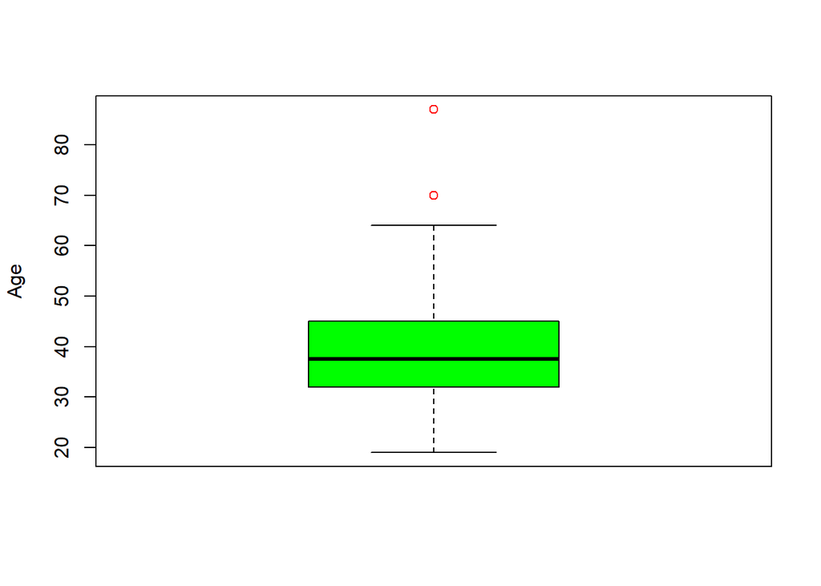

```r
#abline(mean(newPb100k_dec),lwd = 2, col="blue")



boxplot(newAge,ylab="Age",col="green",outcol="red")
```

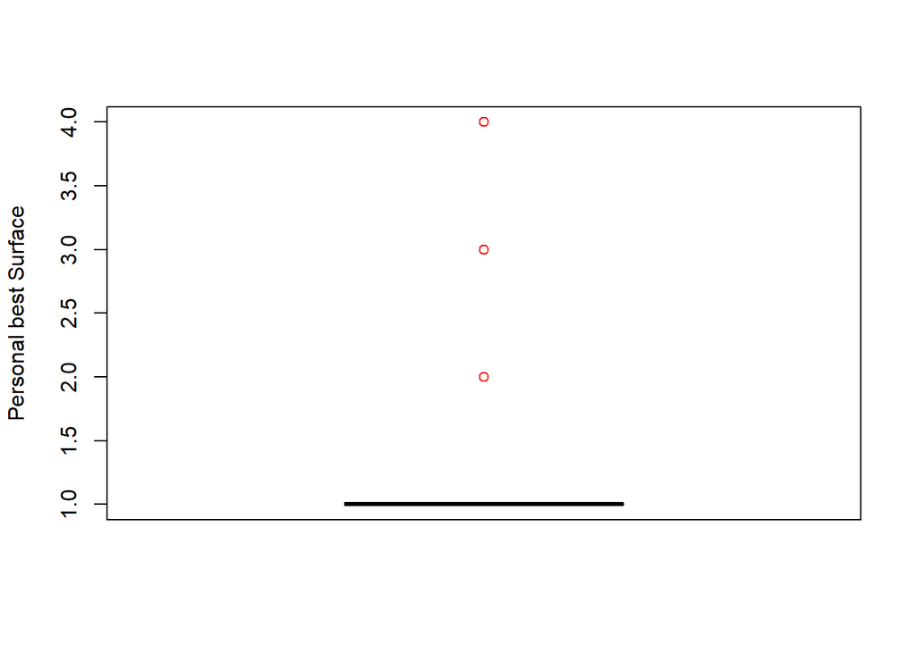

```r
boxplot(newPb_surface,ylab="Personal best Surface", col="darkgreen",outcol = "red")
```

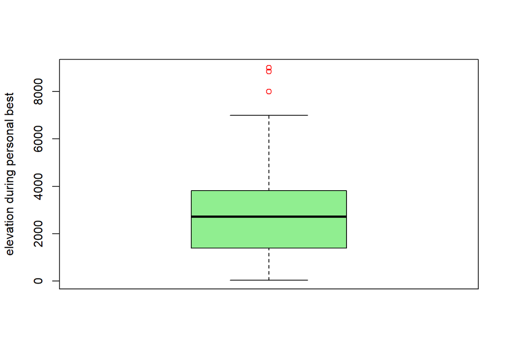

```r
boxplot(newPb_elev, ylab="elevation during personal best",col="lightgreen",outcol="red")
```

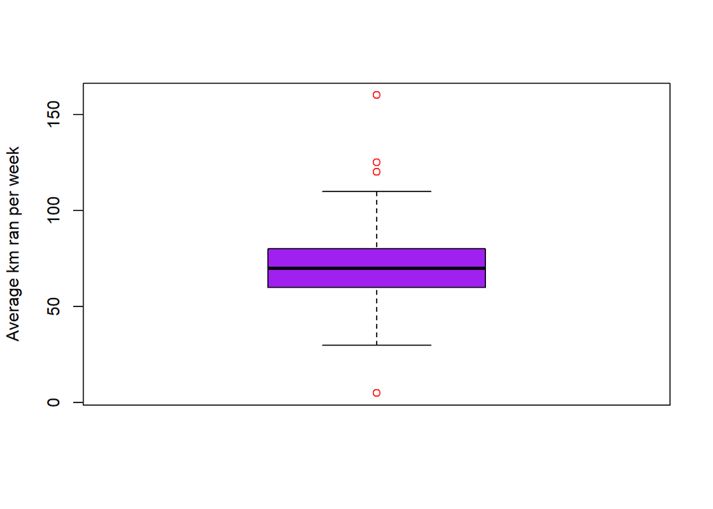

```r
boxplot(newAvg_km,ylab="Average km ran per week",col = "purple",outcol="red")
```

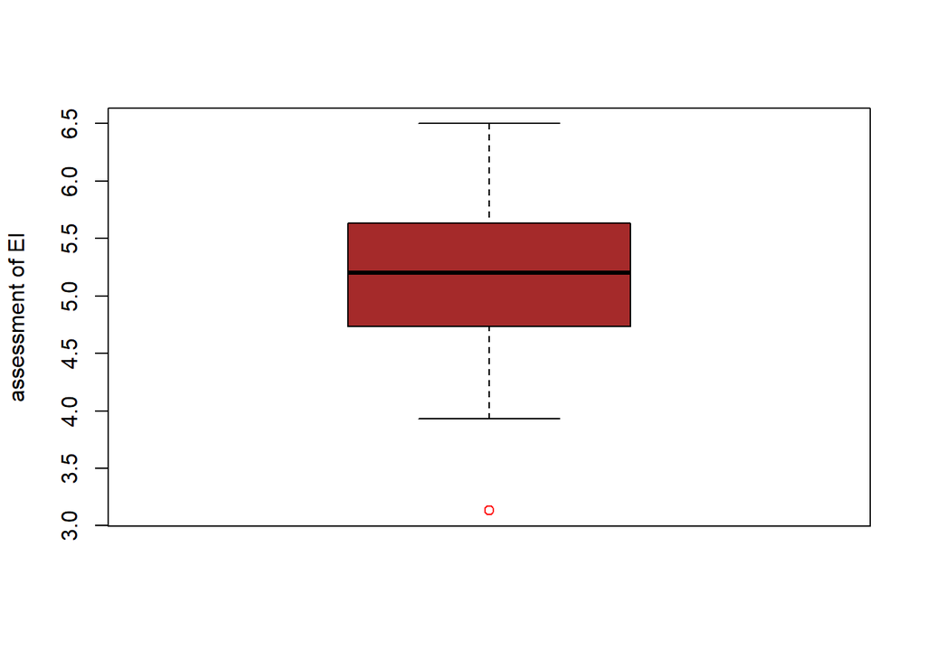

```r
boxplot(newTeique_sf,ylab="assessment of EI",col="brown",outcol="red")
```

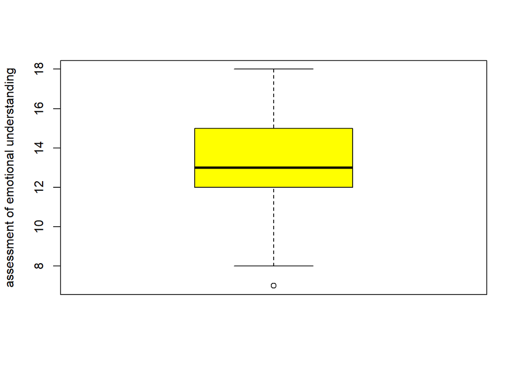

```r
boxplot(newSteu_b,ylab="assessment of emotional understanding",col="yellow")
```

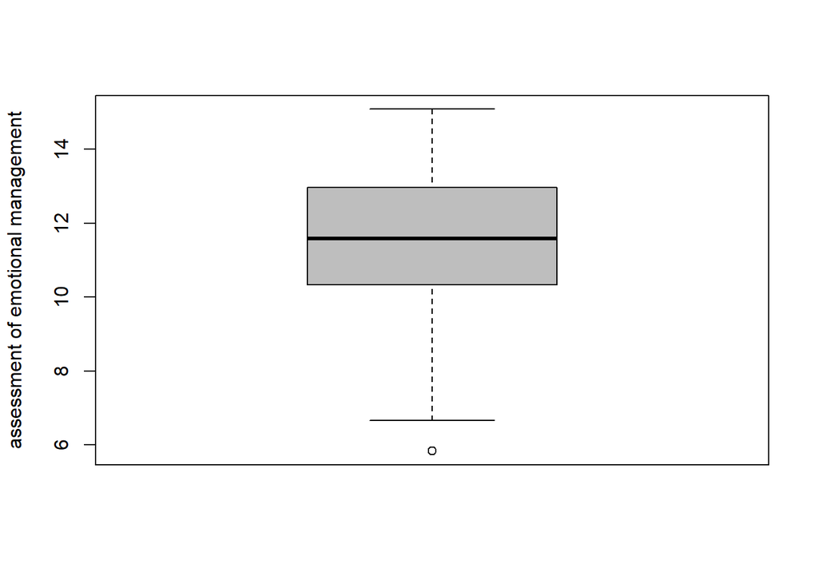

```r
boxplot(newStem_b,ylab="assessment of emotional management",col="gray")

#We're gonna make a violin plot based on our dummy variable of sex

library(ggplot2)
```

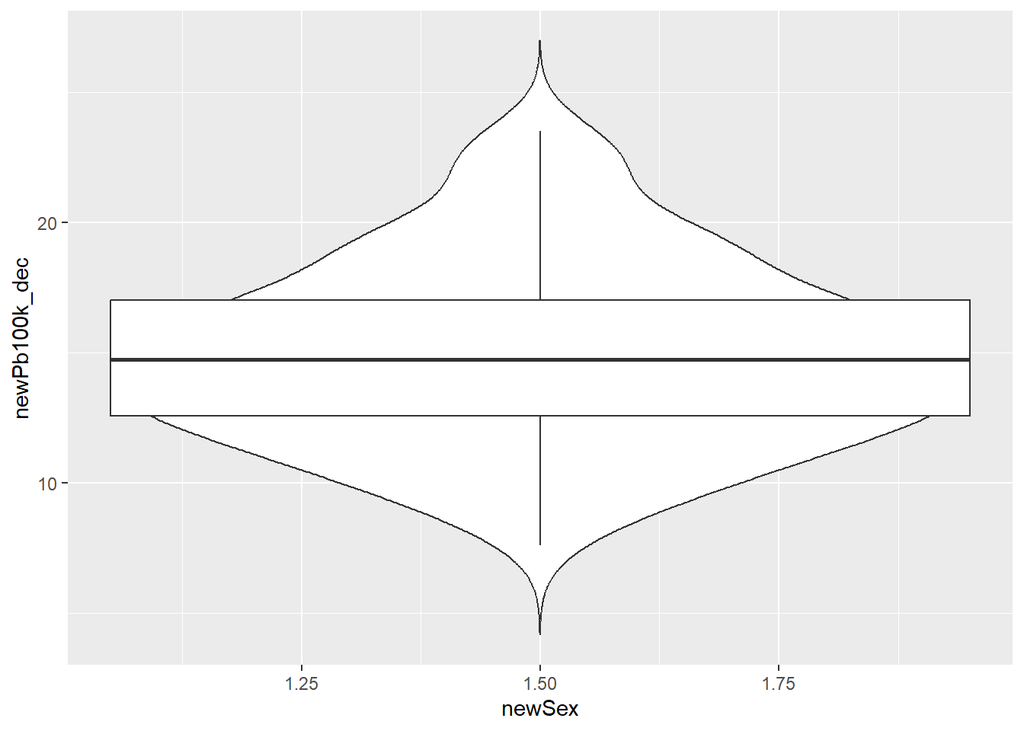

```r
p<-ggplot(Ultrarunning,aes(x=newSex,y=newPb100k_dec,color=newSex))+geom_violin(trim=FALSE)
p+geom_boxplot(width=0.1)
```

In this section of code, we will now be analyzing the scatterplots of the data given.

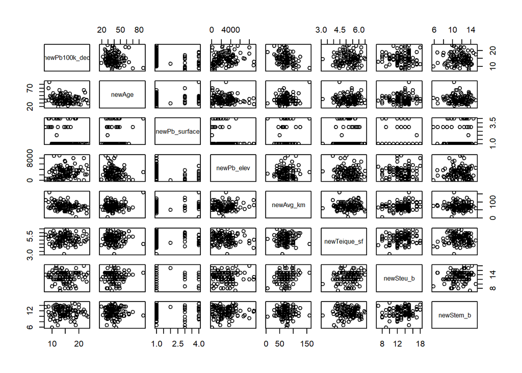

```r
par(mfrow=c(2,2))
pairs(newPb100k_dec~newAge+newPb_surface+ newPb_elev+newAvg_km+newTeique_sf+newSteu_b+newStem_b)
```

Now this is going to make a function that shows the correlation coefficient on the lower panel, and the scatter plots on the upper panel

[output not shown]

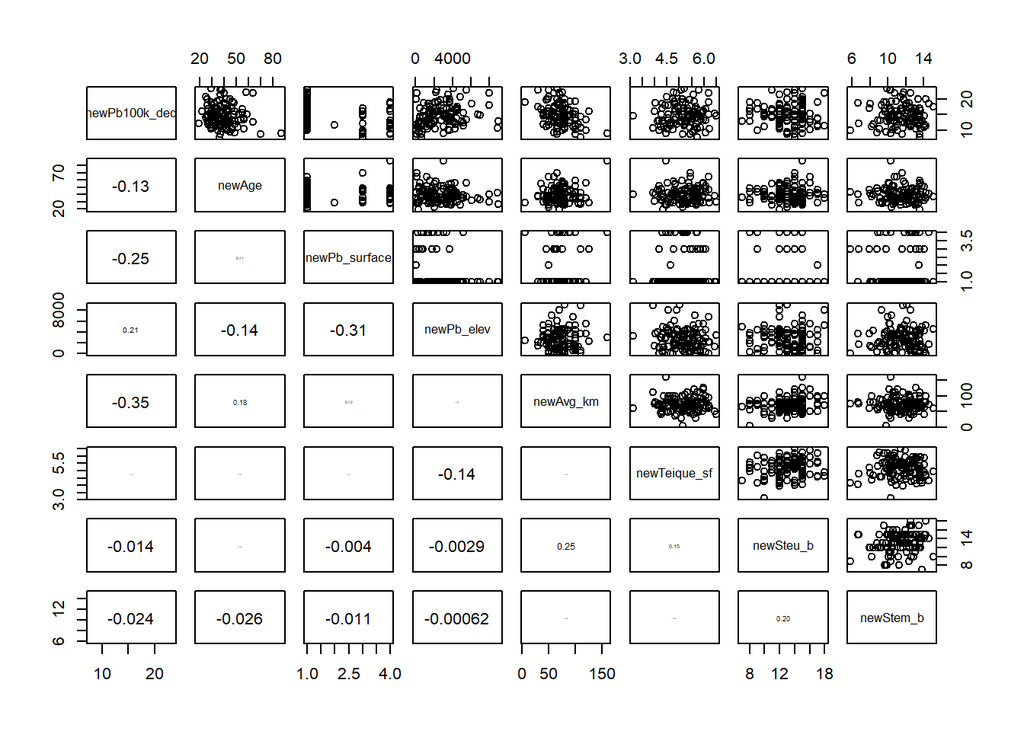

```r
X<-cbind(newPb100k_dec,newAge,newPb_elev,newAvg_km,newTeique_sf,newSteu_b,newStem_b)
panel.cor<-function(x,y,digits=2,prefix="", cex.cor, ...) {
  usr<-par("usr");on.exit(par(usr))
  par(usr=c(0,1,0,1))
  r<-cor(x,y)
  txt<-format(c(r,0.123456789),digits=digits)[1]
  txt<-paste0(prefix,txt)
  if(missing(cex.cor)) cex.cor<-0.8/strwidth(txt)
  text(0.5,0.5,txt,cex=cex.cor*r)
}
pairs(newPb100k_dec~newAge+newPb_surface+ newPb_elev+newAvg_km+newTeique_sf+newSteu_b+newStem_b,lower.panel=panel.cor)
```

Now we have analyzed the individual graphs we can now create our linear model to analyze variable significance, and possible revelations of the qq plot, residual plot and standardized residual plot

```r
m1=lm(newPb100k_dec~newAge+newSex+newPb_surface +newPb_elev+newAvg_km+newTeique_sf+newSteu_b+newStem_b)
summary(m1)
```

```
##
## Call:
## lm(formula = newPb100k_dec ~ newAge + newSex + newPb_surface +
##     newPb_elev + newAvg_km + newTeique_sf + newSteu_b + newStem_b)
##
## Residuals:
##    Min     1Q Median     3Q    Max
## -5.737 -2.159 -0.584  1.885  7.556
##
## Coefficients:
##                 Estimate Std. Error t value Pr(>|t|)
## (Intercept)   17.6561847  3.8288528   4.611 1.15e-05 ***
## newAge        -0.0113037  0.0295673  -0.382 0.703024
## newSex        -0.6192643  0.6873017  -0.901 0.369686
## newPb_surface -0.5162973  0.3066133  -1.684 0.095235 .
## newPb_elev     0.0003482  0.0001716   2.030 0.044968 *
## newAvg_km     -0.0541224  0.0143677  -3.767 0.000275 ***
## newTeique_sf   0.4345594  0.5050296   0.860 0.391532
## newSteu_b      0.1002473  0.1420767   0.706 0.482039
## newStem_b     -0.0936847  0.1735281  -0.540 0.590444
## ---
## Signif. codes:  0 '***' 0.001 '**' 0.01 '*' 0.05 '.' 0.1 ' ' 1
##
## Residual standard error: 3.235 on 103 degrees of freedom
## Multiple R-squared:  0.214,  Adjusted R-squared:  0.1529
## F-statistic: 3.505 on 8 and 103 DF,  p-value: 0.001278
```

Now this section of the code will help us get information about the qqplot,

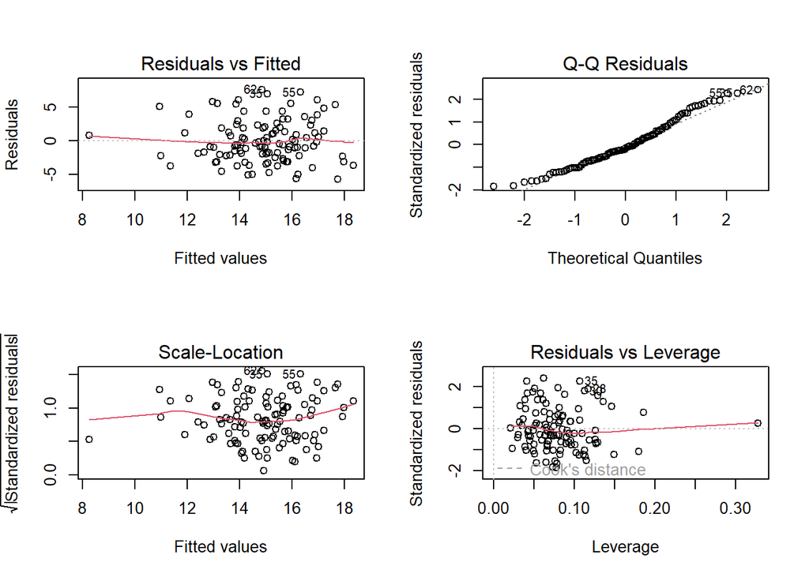

```r
par(mfrow = c(2,2))

plot(m1)
```

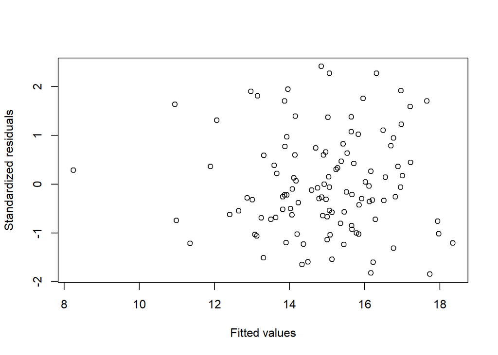

```r
par(mfrow = c(1,1))
plot(m1$fitted.values,rstandard(m1),xlab="Fitted values",ylab="Standardized residuals")
```

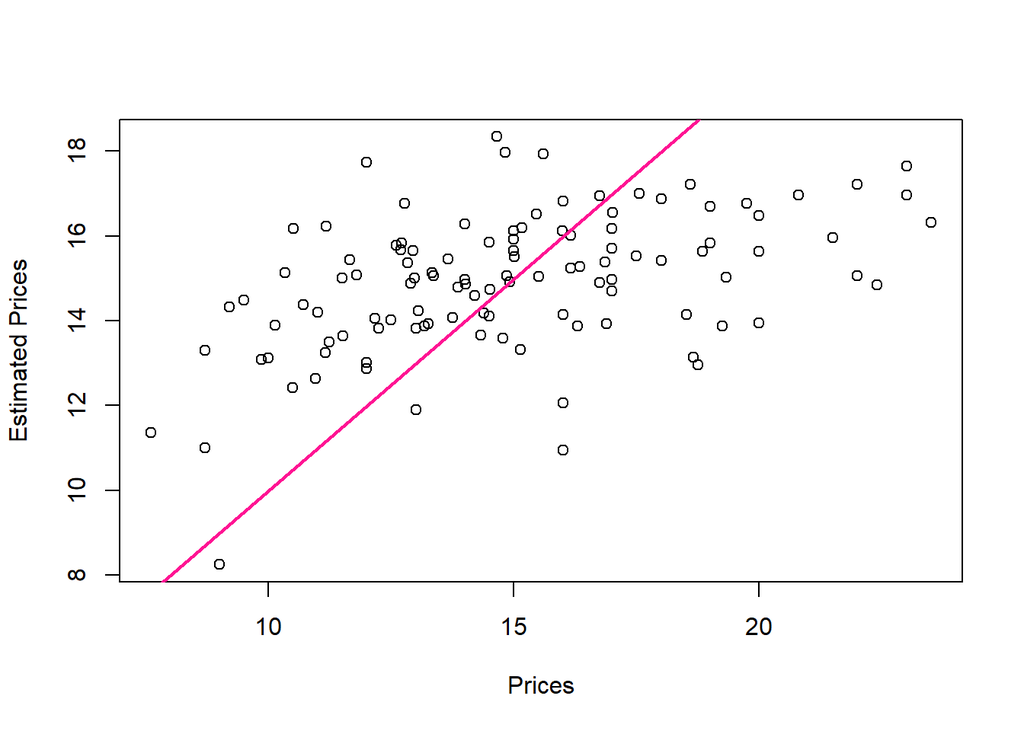

```r
plot(newPb100k_dec,m1$fitted.values,xlab="Prices",ylab="Estimated Prices")
abline(0,1,col="deeppink",lwd=2)
text(22,25,"y=x",col="deeppink")
```

Based on the results of the first model, their may be some issues that prevent us from accurately determing a sufficient model.

```r
library(carData)
library(car)
summary(powerTransform(cbind(newAge,newPb_surface, newPb_elev,newPb100k_dec,newAvg_km,newTeique_sf,newSteu_b,newStem_b)~1), Ultrarunning)
```

```
## bcPower Transformations to Multinormality
##               Est Power Rounded Pwr Wald Lwr Bnd Wald Upr Bnd
## newAge          -0.1804        0.00      -0.7555       0.3947
## newPb_surface   -3.5593       -3.56      -4.3134      -2.8052
## newPb_elev       0.5158        0.50       0.3556       0.6759
## newPb100k_dec    0.0227        0.00      -0.6605       0.7060
## newAvg_km        0.8207        1.00       0.5011       1.1402
## newTeique_sf     1.8497        1.00       0.5232       3.1762
## newSteu_b        1.8410        1.00       0.9876       2.6943
## newStem_b        2.0878        2.00       1.0741       3.1015
##
## Likelihood ratio test that transformation parameters are equal to 0
##  (all log transformations)
##                                          LRT df       pval
## LR test, lambda = (0 0 0 0 0 0 0 0) 270.1089  8 < 2.22e-16
##
## Likelihood ratio test that no transformations are needed
##                                          LRT df       pval
## LR test, lambda = (1 1 1 1 1 1 1 1) 298.1939  8 < 2.22e-16
```

Based on our Box-cox methods, it’s evident that we will need to adjust our Age variable, Pb_elev and Pb100k_dec to create a better model

```r
transformedAge = log(newAge)
transformedPb_surface = (newPb_surface^(-3.56)-1)/(-3.56)
transformedPb_elv = newPb_elev^(1/2)
transformedPb100k_dec = log(newPb100k_dec)
transformedStem_b = newStem_b^2
```

Using these transformed variables, we will now create a new model using these variables.

```r
m2=lm(transformedPb100k_dec~transformedAge+newSex+transformedPb_surface +transformedPb_elv+ newAvg_km+newTeique_sf+newSteu_b+newStem_b)
summary(m2)
```

```
##
## Call:
## lm(formula = transformedPb100k_dec ~ transformedAge + newSex +
##     transformedPb_surface + transformedPb_elv + newAvg_km + newTeique_sf +
##     newSteu_b + newStem_b)
##
## Residuals:
##      Min       1Q   Median       3Q      Max
## -0.42733 -0.14240 -0.01622  0.14221  0.44250
##
## Coefficients:
##                        Estimate Std. Error t value Pr(>|t|)
## (Intercept)            2.962762   0.378632   7.825 4.65e-12 ***
## transformedAge        -0.053772   0.079545  -0.676 0.500556
## newSex                -0.056203   0.045005  -1.249 0.214562
## transformedPb_surface -0.474364   0.190968  -2.484 0.014604 *
## transformedPb_elv      0.002564   0.001121   2.287 0.024260 *
## newAvg_km             -0.003717   0.000929  -4.001 0.000119 ***
## newTeique_sf           0.033178   0.032888   1.009 0.315431
## newSteu_b              0.005096   0.009284   0.549 0.584227
## newStem_b             -0.005630   0.011348  -0.496 0.620876
## ---
## Signif. codes:  0 '***' 0.001 '**' 0.01 '*' 0.05 '.' 0.1 ' ' 1
##
## Residual standard error: 0.2113 on 103 degrees of freedom
## Multiple R-squared:  0.2756, Adjusted R-squared:  0.2193
## F-statistic: 4.897 on 8 and 103 DF,  p-value: 3.837e-05
```

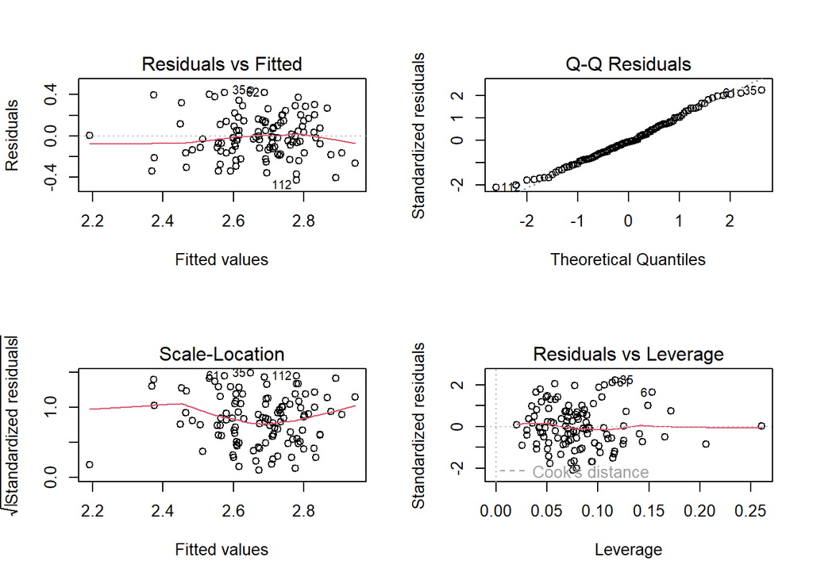

```r
par(mfrow=c(2,2))
plot(m2)
```

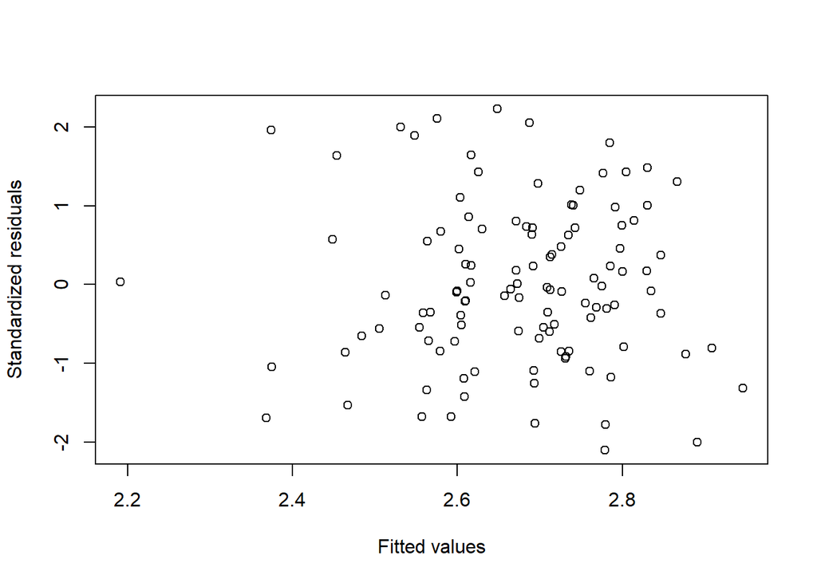

```r
par(mfrow=c(1,1))
plot(m2$fitted.values,rstandard(m2),xlab="Fitted values",
     ylab="Standardized residuals")
```

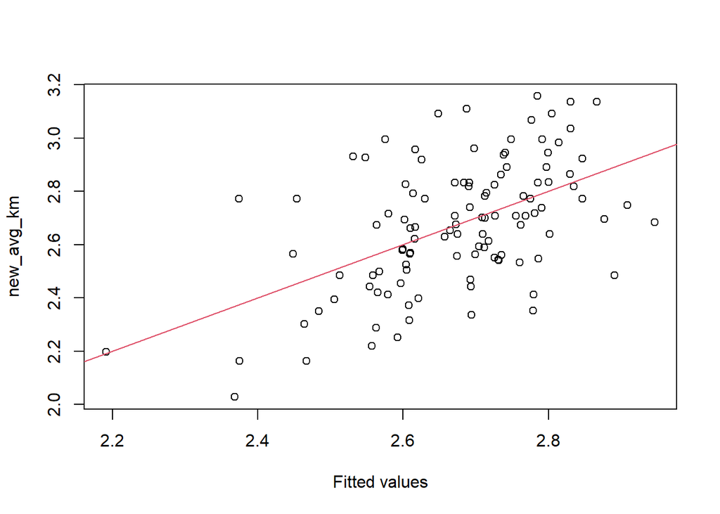

```r
plot(m2$fitted.values,transformedPb100k_dec,xlab="Fitted values",ylab="new_avg_km")
abline(lsfit(m2$fitted.values,transformedPb100k_dec),col=2)
```

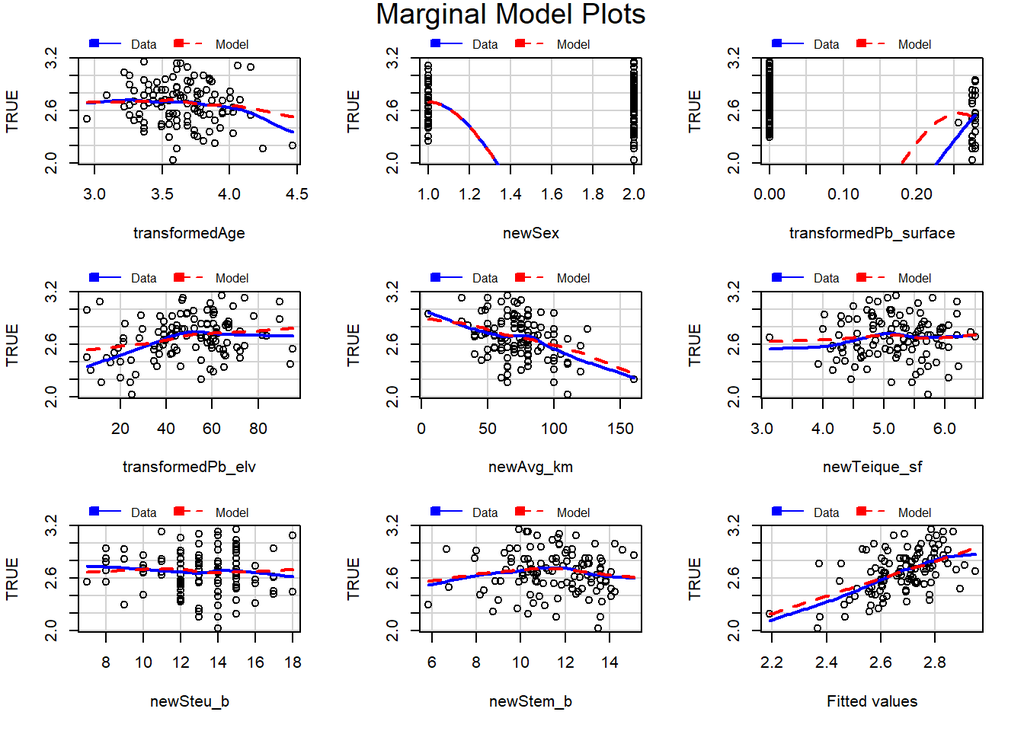

```r
mmps(m2)
```

```r
vif(m1)
```

```
##        newAge        newSex newPb_surface    newPb_elev     newAvg_km
##      1.064623      1.069110      1.130920      1.168761      1.134267
##  newTeique_sf     newSteu_b     newStem_b
##      1.082549      1.150720      1.057721
```

```r
vif(m2)
```

```
##        transformedAge                newSex transformedPb_surface
##              1.044730              1.074096              1.177583
##     transformedPb_elv             newAvg_km          newTeique_sf
##              1.202515              1.111162              1.075688
##             newSteu_b             newStem_b
##              1.151193              1.059975
```

```r
backAIC = step(m2,direction = "backward")
```

```
## Start:  AIC=-339.57
## transformedPb100k_dec ~ transformedAge + newSex + transformedPb_surface +
##     transformedPb_elv + newAvg_km + newTeique_sf + newSteu_b +
##     newStem_b
##
##                         Df Sum of Sq    RSS     AIC
## - newStem_b              1   0.01099 4.6101 -341.31
## - newSteu_b              1   0.01346 4.6126 -341.25
## - transformedAge         1   0.02040 4.6195 -341.08
## - newTeique_sf           1   0.04544 4.6446 -340.47
## - newSex                 1   0.06964 4.6688 -339.89
## <none>                               4.5991 -339.57
## - transformedPb_elv      1   0.23348 4.8326 -336.03
## - transformedPb_surface  1   0.27551 4.8746 -335.06
## - newAvg_km              1   0.71482 5.3139 -325.39
##
## Step:  AIC=-341.31
## transformedPb100k_dec ~ transformedAge + newSex + transformedPb_surface +
##     transformedPb_elv + newAvg_km + newTeique_sf + newSteu_b
##
##                         Df Sum of Sq    RSS     AIC
## - newSteu_b              1   0.00953 4.6196 -343.08
## - transformedAge         1   0.01978 4.6299 -342.83
## - newTeique_sf           1   0.04529 4.6554 -342.21
## - newSex                 1   0.06437 4.6745 -341.75
## <none>                               4.6101 -341.31
## - transformedPb_elv      1   0.23455 4.8447 -337.75
## - transformedPb_surface  1   0.27081 4.8809 -336.91
## - newAvg_km              1   0.70956 5.3197 -327.27
##
## Step:  AIC=-343.08
## transformedPb100k_dec ~ transformedAge + newSex + transformedPb_surface +
##     transformedPb_elv + newAvg_km + newTeique_sf
##
##                         Df Sum of Sq    RSS     AIC
## - transformedAge         1   0.02160 4.6412 -344.55
## - newTeique_sf           1   0.05399 4.6736 -343.77
## - newSex                 1   0.07065 4.6903 -343.38
## <none>                               4.6196 -343.08
## - transformedPb_elv      1   0.23402 4.8537 -339.54
```

[output cut: 20 more lines]

```
## - newSex                 1   0.04977 4.7425 -346.14
## <none>                               4.6927 -345.32
## - transformedPb_elv      1   0.22597 4.9187 -342.05
## - transformedPb_surface  1   0.27440 4.9671 -340.95
## - newAvg_km              1   0.76307 5.4558 -330.44
##
## Step:  AIC=-346.14
## transformedPb100k_dec ~ transformedPb_surface + transformedPb_elv +
##     newAvg_km
##
##                         Df Sum of Sq    RSS     AIC
## <none>                               4.7425 -346.14
## - transformedPb_elv      1   0.20901 4.9515 -343.31
## - transformedPb_surface  1   0.26539 5.0079 -342.04
## - newAvg_km              1   0.76720 5.5097 -331.34
```

```r
n=nrow(Ultrarunning)
backBIC = step(m2,direction="backward",k=log(n))
```

```
## Start:  AIC=-315.11
## transformedPb100k_dec ~ transformedAge + newSex + transformedPb_surface +
##     transformedPb_elv + newAvg_km + newTeique_sf + newSteu_b +
##     newStem_b
##
##                         Df Sum of Sq    RSS     AIC
## - newStem_b              1   0.01099 4.6101 -319.56
## - newSteu_b              1   0.01346 4.6126 -319.50
## - transformedAge         1   0.02040 4.6195 -319.33
## - newTeique_sf           1   0.04544 4.6446 -318.73
## - newSex                 1   0.06964 4.6688 -318.14
## <none>                               4.5991 -315.11
## - transformedPb_elv      1   0.23348 4.8326 -314.28
## - transformedPb_surface  1   0.27551 4.8746 -313.31
## - newAvg_km              1   0.71482 5.3139 -303.65
##
## Step:  AIC=-319.56
## transformedPb100k_dec ~ transformedAge + newSex + transformedPb_surface +
##     transformedPb_elv + newAvg_km + newTeique_sf + newSteu_b
##
##                         Df Sum of Sq    RSS     AIC
## - newSteu_b              1   0.00953 4.6196 -324.05
## - transformedAge         1   0.01978 4.6299 -323.80
## - newTeique_sf           1   0.04529 4.6554 -323.18
## - newSex                 1   0.06437 4.6745 -322.73
## <none>                               4.6101 -319.56
## - transformedPb_elv      1   0.23455 4.8447 -318.72
## - transformedPb_surface  1   0.27081 4.8809 -317.88
## - newAvg_km              1   0.70956 5.3197 -308.24
##
## Step:  AIC=-324.05
## transformedPb100k_dec ~ transformedAge + newSex + transformedPb_surface +
##     transformedPb_elv + newAvg_km + newTeique_sf
##
##                         Df Sum of Sq    RSS     AIC
## - transformedAge         1   0.02160 4.6412 -328.24
## - newTeique_sf           1   0.05399 4.6736 -327.46
## - newSex                 1   0.07065 4.6903 -327.07
## <none>                               4.6196 -324.05
## - transformedPb_elv      1   0.23402 4.8537 -323.23
```

[output cut: 20 more lines]

```
## - newSex                 1   0.04977 4.7425 -335.26
## <none>                               4.6927 -331.73
## - transformedPb_elv      1   0.22597 4.9187 -331.18
## - transformedPb_surface  1   0.27440 4.9671 -330.08
## - newAvg_km              1   0.76307 5.4558 -319.57
##
## Step:  AIC=-335.26
## transformedPb100k_dec ~ transformedPb_surface + transformedPb_elv +
##     newAvg_km
##
##                         Df Sum of Sq    RSS     AIC
## <none>                               4.7425 -335.26
## - transformedPb_elv      1   0.20901 4.9515 -335.15
## - transformedPb_surface  1   0.26539 5.0079 -333.88
## - newAvg_km              1   0.76720 5.5097 -323.19
```

```r
library(leaps)
regit.full = regsubsets(transformedPb100k_dec~transformedAge+newSex + transformedPb_surface +transformedPb_elv+ newAvg_km+newTeique_sf+newSteu_b+newStem_b,data = Ultrarunning,nvmax = 8)
summary(regit.full)
```

```
## Subset selection object
## Call: regsubsets.formula(transformedPb100k_dec ~ transformedAge + newSex +
##     transformedPb_surface + transformedPb_elv + newAvg_km + newTeique_sf +
##     newSteu_b + newStem_b, data = Ultrarunning, nvmax = 8)
## 8 Variables  (and intercept)
##                       Forced in Forced out
## transformedAge            FALSE      FALSE
## newSex                    FALSE      FALSE
## transformedPb_surface     FALSE      FALSE
## transformedPb_elv         FALSE      FALSE
## newAvg_km                 FALSE      FALSE
## newTeique_sf              FALSE      FALSE
## newSteu_b                 FALSE      FALSE
## newStem_b                 FALSE      FALSE
## 1 subsets of each size up to 8
## Selection Algorithm: exhaustive
##          transformedAge newSex transformedPb_surface transformedPb_elv
## 1  ( 1 ) " "            " "    " "                   " "
## 2  ( 1 ) " "            " "    "*"                   " "
## 3  ( 1 ) " "            " "    "*"                   "*"
## 4  ( 1 ) " "            "*"    "*"                   "*"
## 5  ( 1 ) " "            "*"    "*"                   "*"
## 6  ( 1 ) "*"            "*"    "*"                   "*"
## 7  ( 1 ) "*"            "*"    "*"                   "*"
## 8  ( 1 ) "*"            "*"    "*"                   "*"
##          newAvg_km newTeique_sf newSteu_b newStem_b
## 1  ( 1 ) "*"       " "          " "       " "
## 2  ( 1 ) "*"       " "          " "       " "
## 3  ( 1 ) "*"       " "          " "       " "
## 4  ( 1 ) "*"       " "          " "       " "
## 5  ( 1 ) "*"       "*"          " "       " "
## 6  ( 1 ) "*"       "*"          " "       " "
## 7  ( 1 ) "*"       "*"          "*"       " "
## 8  ( 1 ) "*"       "*"          "*"       "*"
```

```r
reg.summary=summary(regit.full)
names(reg.summary)
```

```
## [1] "which"  "rsq"    "rss"    "adjr2"  "cp"     "bic"    "outmat" "obj"
```

```r
reg.summary$adjr2
```

```
## [1] 0.1260462 0.2057533 0.2322362 0.2331928 0.2344471 0.2307526 0.2249580
## [8] 0.2192988
```

```r
reg.summary$bic
```

```
## [1]  -6.666099 -13.681380 -13.793284 -10.256278  -6.772794  -2.576711   1.910526
## [8]   6.361717
```

```r
om1=lm(transformedPb100k_dec~newAvg_km)
om2=lm(transformedPb100k_dec~newAvg_km+transformedPb_surface)
om3=lm(transformedPb100k_dec~newAvg_km+transformedPb_surface+transformedPb_elv)
om4=lm(transformedPb100k_dec~newAvg_km+transformedPb_surface+transformedPb_elv+newSex)
om5=lm(transformedPb100k_dec~newAvg_km+transformedPb_surface+transformedPb_elv+newSex+newTeique_sf)
om6=lm(transformedPb100k_dec~newAvg_km+transformedPb_surface+transformedPb_elv+newSex+newTeique_sf+transformedAge)
om7=lm(transformedPb100k_dec~newAvg_km+transformedPb_surface+transformedPb_elv+newSex+newTeique_sf+transformedAge+newSteu_b)
om8=lm(transformedPb100k_dec~newAvg_km+transformedPb_surface+transformedPb_elv+newSex+newTeique_sf+transformedAge+newSteu_b+newStem_b)

extractAIC(om1,k=2)+2*3*4/(n-2)
```

```
## [1]    2.218182 -333.354935
```

```r
extractAIC(om2,k=2)+2*4*5/(n-2)
```

```
## [1]    3.363636 -342.943260
```

```r
extractAIC(om3,k=2)+2*5*6/(n-2)
```

```
## [1]    4.545455 -345.591844
```

```r
extractAIC(om4,k=2)+2*6*7/(n-2)
```

```
## [1]    5.763636 -344.555156
```

```r
extractAIC(om5,k=2)+2*7*8/(n-2)
```

```
## [1]    7.018182 -343.535626
```

```r
extractAIC(om6,k=2)+2*8*9/(n-2)
```

```
## [1]    8.309091 -341.767132
```

```r
extractAIC(om7,k=2)+2*9*10/(n-2)
```

```
## [1]    9.636364 -339.671121
```

```r
extractAIC(om8,k=2)+2*10*11/(n-2)
```

```
## [1]   11.0000 -337.5748
```

```r
summary(om3)
```

```
##
## Call:
## lm(formula = transformedPb100k_dec ~ newAvg_km + transformedPb_surface +
##     transformedPb_elv)
##
## Residuals:
##      Min       1Q   Median       3Q      Max
## -0.43165 -0.13800 -0.00867  0.12319  0.43447
##
## Coefficients:
##                         Estimate Std. Error t value Pr(>|t|)
## (Intercept)            2.8508151  0.0857088  33.262  < 2e-16 ***
## newAvg_km             -0.0036766  0.0008796  -4.180 5.94e-05 ***
## transformedPb_surface -0.4645611  0.1889710  -2.458   0.0155 *
## transformedPb_elv      0.0023855  0.0010934   2.182   0.0313 *
## ---
## Signif. codes:  0 '***' 0.001 '**' 0.01 '*' 0.05 '.' 0.1 ' ' 1
##
## Residual standard error: 0.2096 on 108 degrees of freedom
## Multiple R-squared:  0.253,  Adjusted R-squared:  0.2322
## F-statistic: 12.19 on 3 and 108 DF,  p-value: 6.225e-07
```

```r
anova(om1,om2,om3,om4,om5,om6,om7,om8)
```

```
## Analysis of Variance Table
##
## Model 1: transformedPb100k_dec ~ newAvg_km
## Model 2: transformedPb100k_dec ~ newAvg_km + transformedPb_surface
## Model 3: transformedPb100k_dec ~ newAvg_km + transformedPb_surface + transformedPb_elv
## Model 4: transformedPb100k_dec ~ newAvg_km + transformedPb_surface + transformedPb_elv +
##     newSex
## Model 5: transformedPb100k_dec ~ newAvg_km + transformedPb_surface + transformedPb_elv +
##     newSex + newTeique_sf
## Model 6: transformedPb100k_dec ~ newAvg_km + transformedPb_surface + transformedPb_elv +
##     newSex + newTeique_sf + transformedAge
## Model 7: transformedPb100k_dec ~ newAvg_km + transformedPb_surface + transformedPb_elv +
##     newSex + newTeique_sf + transformedAge + newSteu_b
## Model 8: transformedPb100k_dec ~ newAvg_km + transformedPb_surface + transformedPb_elv +
##     newSex + newTeique_sf + transformedAge + newSteu_b + newStem_b
##   Res.Df    RSS Df Sum of Sq       F    Pr(>F)
## 1    110 5.4984
## 2    109 4.9515  1   0.54689 12.2480 0.0006895 ***
## 3    108 4.7425  1   0.20901  4.6809 0.0328116 *
## 4    107 4.6927  1   0.04977  1.1145 0.2935696
## 5    106 4.6412  1   0.05146  1.1525 0.2855317
## 6    105 4.6196  1   0.02160  0.4837 0.4883147
## 7    104 4.6101  1   0.00953  0.2134 0.6450844
## 8    103 4.5991  1   0.01099  0.2461 0.6208760
## ---
## Signif. codes:  0 '***' 0.001 '**' 0.01 '*' 0.05 '.' 0.1 ' ' 1
```

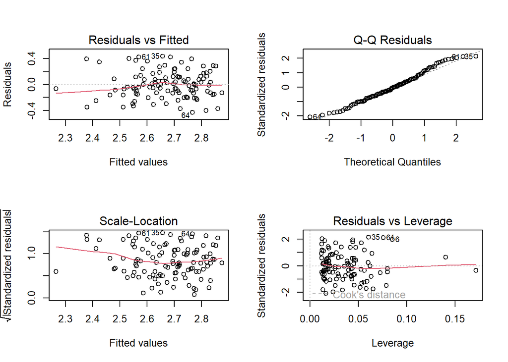

```r
par(mfrow=c(2,2))
plot(om3)
```

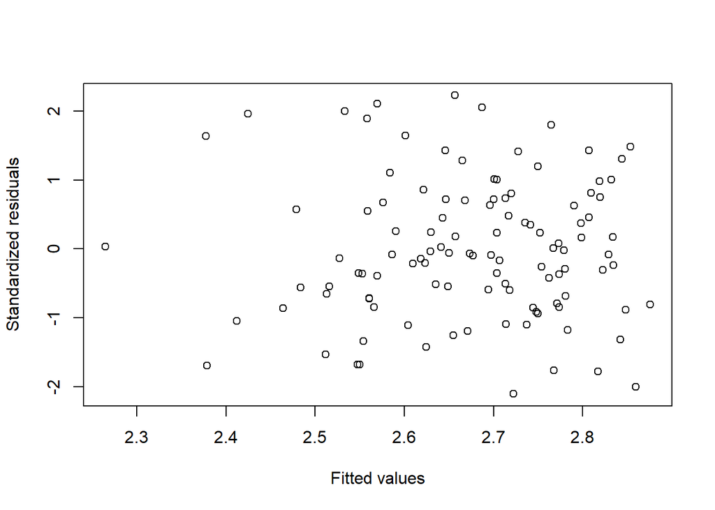

```r
par(mfrow=c(1,1))
plot(om3$fitted.values,rstandard(m2),xlab="Fitted values",
     ylab="Standardized residuals")
```

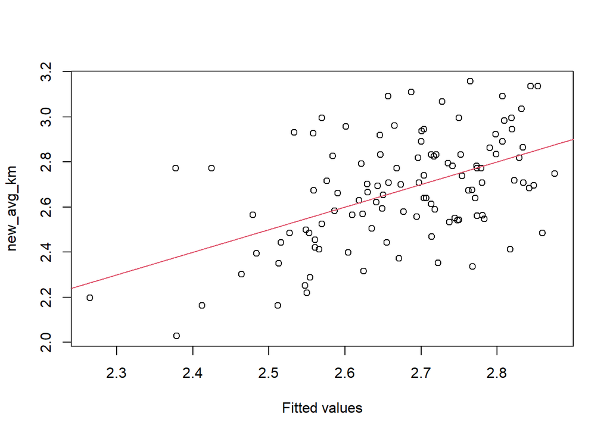

```r
plot(om3$fitted.values,transformedPb100k_dec,xlab="Fitted values",ylab="new_avg_km")
abline(lsfit(m2$fitted.values,transformedPb100k_dec),col=2)
```

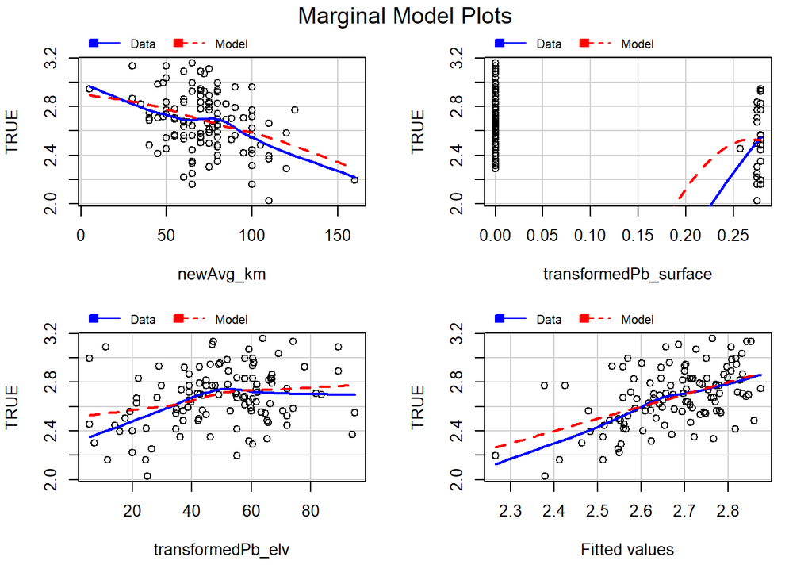

```r
mmps(om3)
```

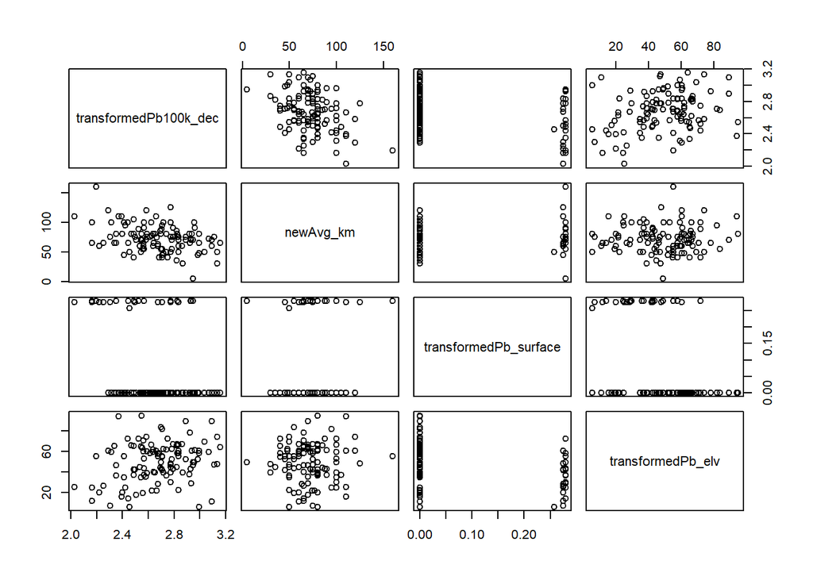

```r
pairs(transformedPb100k_dec~newAvg_km+transformedPb_surface+transformedPb_elv)
```